# Sensitivity Analysis for Quality Filtering Parameters

## Note for editors: Need to switch around the eval=FALSE chunks before publishing

The purpose of this vignette is to demonstrate how a researcher can test the effects of various DADA2 quality filtering parameter combinations on the outputs of the DADA2 pipeline, and ultimately, on the ecological inference. Specifically, this vignette asks the following from a subset of NEON 16S marker gene sequences:

- What are the effects of quality filtering parameters on the number of remaining reads?
- What are the effects of quality filtering parameters on alpha and beta diversity metrics?

The parameters that we vary to observe their downstream effects include the following:

- `trunLen.R`: Reverse reads that do not meet or exceed `truncLen.R` in length will be discarded. Reverse reads that exceed `truncLen.R` will be truncated to `truncLen.R`.
- `maxEE.R`: After truncation, reads with higher than `maxEE` expected errors will be discarded. Expected errors are calculated from the nominal definition of the quality score: EE = sum(10^(-Q/10)).

Because we are interested in variation in these benchmark metrics across different parameter sets, we refer to this analysis as a **sensitivity analysis**. This vignette is intended to provide a boilerplate for users of this R package to construct their own sensitivity analyses.

**Note:** If you are using this vignette as a reference, rather than running it as an RMarkdown script, be aware that you will need to manually set the working directory to the project root directory, e.g. `setwd(".../neonSoilMicrobeProcessing")`.

# Dependencies

To begin, ensure that you have installed all dependencies.

Load libraries:

```r
library(dada2)
library(ShortRead)
library(Biostrings)
library(tibble)
library(dplyr)
library(vegan)
library(phyloseq)
library(ggplot2)
library(tidyr)
```

In addition, source files associated with this package:

```r
source("./R/utils.R")
source("./code/params.R")
```

## Constants used for this sensitivity analysis:

Quality filter parameters that we do not vary in this sensitivity analysis

```r
MAX_EE_FWD <- 8
TRUNC_LEN_FWD <- 240
MIN_LEN <- 50
```

Parameters specific to this sensitivity analysis

```r
N_SAMPLES <- 40
DIRNAME_TEST <- "qf_test_12-30-2020"
runIDs <- c("C5B2R", "CBTWG")
```

Parameter value grid. The following allows testing of two quality filtering parameters at a time.

```r
PARAM1 <- "maxEE.R"
PARAM2 <- "truncLen.R"
grid <- expand.grid(c(4, 8, 16), c(160, 220, 250))
params <- matrix(
  c(grid[,1],     # PARAM1
    grid[,2]),    # PARAM2
  byrow=FALSE, ncol=2,
  dimnames = list(NULL, c(PARAM1, PARAM2))
)
param_sets <- apply(params, 1, function(x) paste(c(rbind(c(PARAM1, PARAM2), x)), collapse="_"))
```

# Assign filepath variables

```r
if(is.null(PRESET_OUTDIR_SEQUENCE) | PRESET_OUTDIR_SEQUENCE == "") {
  PATH_16S <- file.path(PRESET_OUTDIR, "raw_sequence", "16S")
} else {
  PATH_16S <- file.path(PRESET_OUTDIR, PRESET_OUTDIR_SEQUENCE, "16S")
}
PATH_RAW <- file.path(PATH_16S, "0_raw")
PATH_TRIMMED <- file.path(PATH_16S, "1_trimmed")
PATH_TEST <- file.path(PATH_16S, DIRNAME_TEST)
dir.create(file.path(PATH_TEST, "results"))
```

## Get fastq files for this analysis

Retrieve files that match the sequence run IDs specified earlier. In this example, these are “C5B2R” and “CBTWG.”

```r
rawFs <- sort(list.files(PATH_RAW, pattern = paste0("(",paste0("(", runIDs, ")", collapse="|"),")", ".*_R1\\.fastq"), full.names = TRUE))
rawRs <- sort(list.files(PATH_RAW, pattern = paste0("(",paste0("(", runIDs, ")", collapse="|"),")", ".*_R2\\.fastq"), full.names = TRUE))
```

Remove any files that only have forward or reverse reads

```r
matched_fn <- remove_unmatched_files(rawFs, rawRs)
rawFs <- matched_fn[[1]]
rawRs <- matched_fn[[2]]
```

To cut down on computation time, select up to N_SAMPLES samples from the runs, up to N_SAMPLES/length(runIDs) from each run.

```r
if(length(rawFs) > N_SAMPLES) {
  rawFs_subset <- c()
  rawRs_subset <- c()
  for(i in 1:length(runIDs)) {
    rawFs_runID <- rawFs[grep(runIDs[i], rawFs)]
    rawRs_runID <- rawRs[grep(runIDs[i], rawRs)]
    if(length(rawFs_runID) > 5) {
      rawFs_subset <- c(rawFs_subset, rawFs_runID[round(quantile(1:length(rawFs_runID), probs=seq(0,1,length.out=N_SAMPLES/length(runIDs))))])
      rawRs_subset <- c(rawRs_subset, rawRs_runID[round(quantile(1:length(rawRs_runID), probs=seq(0,1,length.out=N_SAMPLES/length(runIDs))))])
    } else {
      rawFs_subset <- c(rawFs_subset, rawFs_runID)
      rawRs_subset <- c(rawRs_subset, rawRs_runID)
    }
  }
  rawFs <- rawFs_subset
  rawRs <- rawRs_subset
}
```

Plot quality profiles

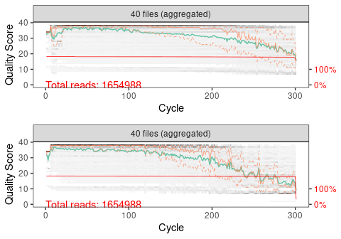

```r
gridExtra::grid.arrange(plotQualityProfile(rawFs, aggregate=TRUE),
                        plotQualityProfile(rawRs, aggregate=TRUE))
```

Split complete filenames into “basenames” and directory names

```r
fn_base <- basename(c(rawFs, rawRs))
PATH_PARAMSETS <- file.path(PATH_TEST, param_sets)
```

## Trim primers from sequences

Trim reads based on the primer sequences supplied in `params.R`.

```r
trim_trackReads <- trimPrimers16S(fn_base, PATH_RAW, PATH_TRIMMED, "CCTACGGGNBGCASCAG", "GACTACNVGGGTATCTAATCC")
```

## Run quality filter on sequences

To store the results arising from each set of parameter choices, we construct a list object where each element corresponds to the output given a different parameter set. For this step, the list object is `filter_trackReads`.

```r
filter_trackReads <- list()
for(i in 1:length(param_sets)) {
  filter_trackReads[[i]] <- qualityFilter16S(
    fn_base,
    PATH_TRIMMED,
    PATH_PARAMSETS[[i]],
    maxEE=c(MAX_EE_FWD, params[i,1]), # Vary maxEE.R
    truncLen=c(TRUNC_LEN_FWD, params[i,2]), # Vary truncLen.R
    minLen=MIN_LEN,
    multithread=MULTITHREAD)
  rownames(filter_trackReads[[i]]) <- paste0(param_sets[i], "|", rownames(filter_trackReads[[i]]))
}
filter_trackReads_mat <- do.call(rbind, filter_trackReads)
```

## Run the rest of the processing pipeline

This requires us to redefine the list structure so that it becomes nested: in the first level, each element corresponds to a parameter set; in the second level, each element corresponds to a sequencing run ID. This is necessary because the dada sequence inference algorithm is sensitive to error rate estimates, and error rates may differ considerably between sequencing runs. Here we initialize the nested list structure for two types of outputs simultaneously.

```r
seqtabs <- dada_trackReads <- lapply(1:length(param_sets), function(x) lapply(1:length(runIDs), function(y) list()))
```

Now we continue with the processing pipeline to produce different versions of the resulting sequence tables.

```r
for(i in 1:length(param_sets)) {
  for(j in 1:length(runIDs)) {
    message("Sensitivity analysis: parameter set ", param_sets[i], ", sequencing run ",  runIDs[j])

    # Retrieve only those files associated with the appropriate parameter set and runID
    fn_base.star <- grep(runIDs[j], fn_base, value=TRUE)

    seqtab.list <- runDada16S(fn_base.star, PATH_PARAMSETS[i], MULTITHREAD, VERBOSE, seed=11001100)
    seqtabs[[i]][[j]] <- seqtab.list$seqtab.nochim
    dada_trackReads[[i]][[j]] <- seqtab.list$track

    rownames(seqtabs[[i]][[j]]) <- paste0(param_sets[i], "|", rownames(seqtabs[[i]][[j]]))
    rownames(dada_trackReads[[i]][[j]]) <- paste0(param_sets[i], "|", rownames(dada_trackReads[[i]][[j]]))
  }
}

dada_trackReads_mat <- do.call(rbind, lapply(dada_trackReads, function(x) do.call(rbind, x)))
```

Combine all read-tracking tables:

```r
trim_trackReads_mat <- do.call(rbind, lapply(1:length(param_sets), function(i) {
  rownames(trim_trackReads) <- paste0(param_sets[i], "|", rownames(trim_trackReads))
  trim_trackReads
}))

track <- Reduce(
  function(x, y, ...) transform(merge(x, y, by=0, all = TRUE, ...), row.names=Row.names, Row.names=NULL),
  list(trim_trackReads_mat[,1],
       filter_trackReads_mat,
       dada_trackReads_mat)
)
names(track) <- c("input", "trimmed", "filtered", colnames(dada_trackReads_mat))
track[is.na(track)] <- 0
```

Now that sequence inference is complete, we can join the sequencing runs back together in each parameter set:

```r
seqtabs_joinrun <- lapply(1:length(param_sets), function(x) list())
for(i in 1:length(param_sets)) {
  seqtabs_joinrun[[i]] <- mergeSequenceTables(tables = seqtabs[[i]])
}
```

Save the data so far:

```r
saveRDS(seqtabs_joinrun, file.path(PATH_TEST, "results", "sensitivity_seqtabs_joinrun_list.Rds"))
write.csv(track, file.path(PATH_TEST, "results", "sensitivity_trackReads.csv"), row.names=TRUE)
```

You can reload RDS objects into R to pick up where you left off:

```r
seqtabs_joinrun <- readRDS(file.path(PATH_TEST, "results", "sensitivity_seqtabs_joinrun_list.Rds"))
track <- read.csv(file.path(PATH_TEST, "results", "sensitivity_trackReads.csv"), row.names=1)
```

## Sensitivity of read counts

We can now plot the number of reads remaining after each step in the processing pipeline.

First, add parameter information to the read tracking table. This custom function simply parses the parameter sets from the rownames of the tracking table.

```r
track <- parseParamsFromRownames(track, PARAM1, PARAM2)
```

Next, perform a few more operations to make the tracking table ready for plotting:

```r
# Reshape read tracking table
track_long <- tidyr::gather(track, key = "step", value = "reads", input:nonchim)
# Exclude metrics associated only with forward reads
track_long <- track_long[!grepl("F$", track_long$step),]
# Aggregate read counts by run ID
track_long[["step"]] <- factor(track_long[["step"]], levels=colnames(track)[1:9])
track_aggRun <- group_by(track_long, maxEE.R, truncLen.R, runID, step) %>%
  dplyr::summarise(reads = sum(reads))
```

Plot!

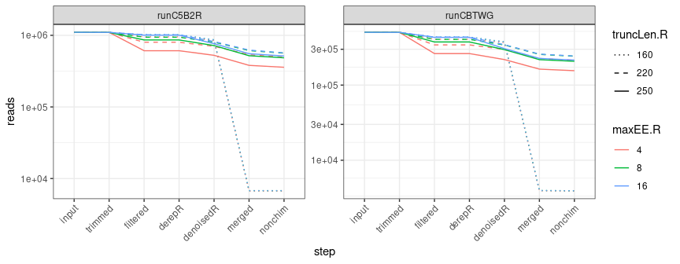

```r
theme_set(theme_bw())
ggplot(track_aggRun, aes(x=step, y=reads, col=as.factor(maxEE.R))) +
  geom_line(aes(linetype=as.factor(truncLen.R), group=interaction(maxEE.R, truncLen.R))) +
  facet_wrap(~runID, scales="free_y") +
  labs(linetype="truncLen.R", color="maxEE.R") +
  scale_linetype_manual(values=c("dotted", "dashed", "solid")) +
  theme(axis.text.x = element_text(angle=45, hjust=1)) +
  scale_y_continuous(trans="log10")
```

```r
ggsave(file.path(PATH_TEST, "results", "track_reads_plot.png"), width=9, height=3.5, units="in")
```

## Sensitivity of alpha diversity

First, we convert the sequence tables into phyloseq objects.

```r
physeqs <- list() # Create a list of physeq objects
for(i in 1:length(param_sets)) {
  # Sample data (parameters)
  sampledata <- parseParamsFromRownames(seqtabs_joinrun[[i]], PARAM1, PARAM2, keep_rownames=TRUE, keep_original_cols = FALSE)
  physeqs[[i]] <- phyloseq(otu_table(seqtabs_joinrun[[i]], taxa_are_rows=FALSE),
                           sample_data(sampledata))
}
```

We make use of `phyloseq`’s `estimate_richness()` function.

```r
obsrich_list <- shannon_list <- list()
for(i in 1:length(physeqs)) {
  div <- suppressWarnings(
    estimate_richness(physeqs[[i]], measures=c("Observed","Shannon"), split=TRUE)
  )
  obsrich_list[[i]] <- div[,1]
  shannon_list[[i]] <- div[,2]
}

diversity_list <- lapply(seq_along(physeqs), function(i) {
  parseParamsFromRownames(
    cbind(
      sample_data(physeqs[[i]]),
      obsrich = obsrich_list[[i]],
      shannon = shannon_list[[i]]
    ),
    PARAM1, PARAM2
  )
})

diversity_df <- do.call(rbind, diversity_list)
```

Plot!

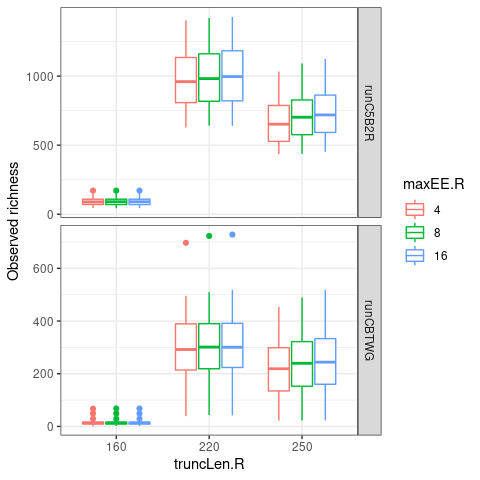

```r
theme_set(theme_bw())
ggplot(diversity_df, aes(y=obsrich, col=as.factor(maxEE.R), x=as.factor(truncLen.R))) +
  geom_boxplot() +
  facet_grid(runID~., scales="free_y") +
  labs(col="maxEE.R", x="truncLen.R") +
  ylab("Observed richness")
```

```r
ggsave(file.path(PATH_TEST, "results", "diversity_plot_obsrich.png"), width=5, height=5, units="in")
```

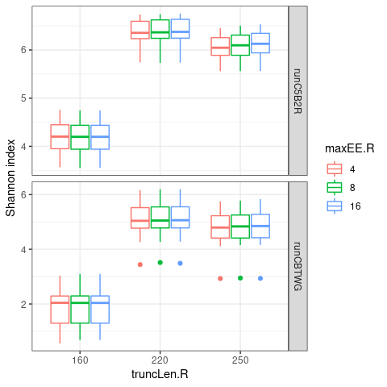

```r
theme_set(theme_bw())
ggplot(diversity_df, aes(y=shannon, col=as.factor(maxEE.R), x=as.factor(truncLen.R))) +
  geom_boxplot() +
  facet_grid(runID~., scales="free_y") +
  labs(col="maxEE.R", x="truncLen.R") +
  ylab("Shannon index")
```

```r
ggsave(file.path(PATH_TEST, "results", "diversity_plot_shannon.png"), width=5, height=5, units="in")
```

Test statistical significance using ANOVA

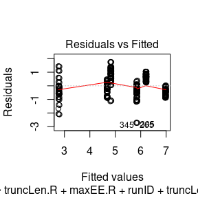

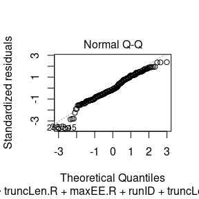

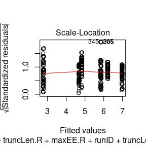

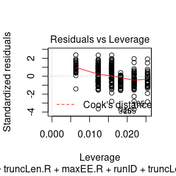

```r
obsrich_aov <- aov(log(obsrich) ~ truncLen.R + maxEE.R + runID + truncLen.R:runID + maxEE.R:runID, data=diversity_df)
plot(obsrich_aov)
```

```r
summary(obsrich_aov)
```

```
#>                   Df Sum Sq Mean Sq F value   Pr(>F)
#> truncLen.R         1  446.6   446.6 799.171  < 2e-16 ***
#> maxEE.R            1    0.1     0.1   0.164    0.685
#> runID              1  194.5   194.5 348.079  < 2e-16 ***
#> truncLen.R:runID   1    9.1     9.1  16.346 6.48e-05 ***
#> maxEE.R:runID      1    0.0     0.0   0.001    0.978
#> Residuals        354  197.8     0.6
#> ---
#> Signif. codes:  0 '***' 0.001 '**' 0.01 '*' 0.05 '.' 0.1 ' ' 1
```

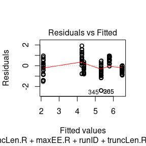

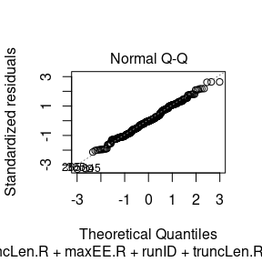

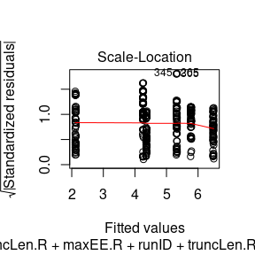

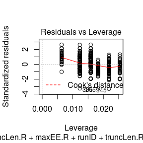

```r
shannon_aov <- aov(shannon ~ truncLen.R + maxEE.R + runID + truncLen.R:runID + maxEE.R:runID, data=diversity_df)
plot(shannon_aov)
```

```r
summary(shannon_aov)
```

```
#>                   Df Sum Sq Mean Sq F value   Pr(>F)
#> truncLen.R         1  440.3   440.3 810.697  < 2e-16 ***
#> maxEE.R            1    0.0     0.0   0.077    0.782
#> runID              1  242.2   242.2 446.041  < 2e-16 ***
#> truncLen.R:runID   1   18.3    18.3  33.672 1.45e-08 ***
#> maxEE.R:runID      1    0.0     0.0   0.000    0.996
#> Residuals        354  192.3     0.5
#> ---
#> Signif. codes:  0 '***' 0.001 '**' 0.01 '*' 0.05 '.' 0.1 ' ' 1
```

**In conclusion,** `truncLen.R` affects alpha-diversity inference, whereas `maxEE.R` does not (within the range of `maxEE.R` values that we tested). `truncLen.R` affects alpha-diversity inference to a different degree depending on the sequence run.

## Sensitivity of beta diversity

First, combine all sequence tables into ONE large sequence table. A sample data table will distinguish samples processed using different parameters.

```r
seqtab_joined <- mergeSequenceTables(tables=seqtabs_joinrun)

# Sample data (parameters)
sampledata <- parseParamsFromRownames(seqtab_joined, PARAM1, PARAM2, keep_rownames=TRUE, keep_original_cols = FALSE)
```

Next, assign taxonomy. Warning: this can take up to several hours.

```r
taxa_joined <- assignTaxonomy(seqtab_joined, UNITE_REF_PATH, multithread = MULTITHREAD, tryRC = TRUE)
saveRDS(taxa_joined, file.path(PATH_TEST, "results", "sensitivity_taxa_joined.Rds"))
```

If you’ve already done the previous step, you can reload the object here.

```r
taxa_joined <- readRDS(file.path(PATH_TEST, "results", "sensitivity_taxa_joined.Rds"))
```

Combine all three tables (sequence table, sample data table, and taxonomy table) into a phyloseq object:

```r
physeq_joined <- phyloseq(otu_table(seqtab_joined,taxa_are_rows=FALSE),
                          sample_data(sampledata),
                          tax_table(taxa_joined))
```

Remove samples with zero total counts

```r
physeq_joined_nonzero <- prune_samples(sample_sums(physeq_joined) > 0, physeq_joined)
```

Optionally, discard taxa with 10 or fewer reads:

```r
physeq_joined_nonzero <- prune_taxa(taxa_sums(physeq_joined) > 10, physeq_joined)
```

Ordinate. Choose one of the sequencing runs to ordinate upon. (Samples from different sequencing runs may be highly dissimilar, producing difficult-to-interpret ordination plots.)

```r
physeq_joined_nonzero_runC5B2R <- subset_samples(physeq_joined_nonzero, runID=="runC5B2R")
set.seed(1010101)
ordination_runC52BR <- ordinate(physeq_joined_nonzero_runC5B2R, "NMDS", "bray", k=2)
```

```
#> Square root transformation
#> Wisconsin double standardization
#> *** No convergence -- monoMDS stopping criteria:
#>      2: no. of iterations >= maxit
#>     15: stress ratio > sratmax
#>      3: scale factor of the gradient < sfgrmin
```

```r
saveRDS(ordination_runC52BR, file.path(PATH_TEST, "results", "sensitivity_ordination_runC5B2R.Rds"))

# physeq_joined_nonzero_runCBTWG <- subset_samples(physeq_joined_nonzero, runID=="runCBTWG")
# set.seed(1010101)
# ordination_runCBTWG <- ordinate(physeq_joined_nonzero_runCBTWG, "NMDS", "bray", k=2)
# saveRDS(ordination_runCBTWG, file.path(PATH_TEST, "results", "sensitivity_ordination_runCBTWG.Rds"))
```

Plot the ordination!

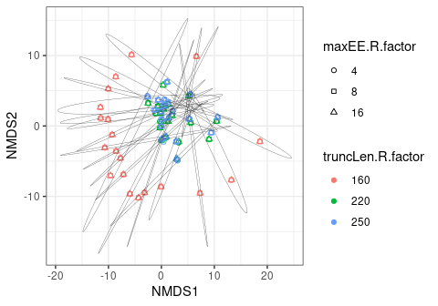

```r
# theme_set(theme_bw())
# sample_data(physeq_joined_nonzero)[,"maxEE.R.factor"] <- as.factor(get_variable(physeq_joined_nonzero, "maxEE.R"))
# plot_ordination(physeq_joined_nonzero, ordination, type="samples",
#                 col="runID", shape="maxEE.R.factor") +
#   stat_ellipse(aes(x=NMDS1, y=NMDS2, col=runID), data=)
#   # coord_cartesian(xlim=c(-0.096, -0.09), ylim=c(-0.002, 0.001)) +
#   NULL
# ggsave(file.path(PATH_TEST, "results", "sensitivity_ordination.png"), width=5, height=3.5, units="in")

# Single-run version
theme_set(theme_bw())
sample_data(physeq_joined_nonzero_runC5B2R)[,"maxEE.R.factor"] <- as.factor(get_variable(physeq_joined_nonzero_runC5B2R, "maxEE.R"))
sample_data(physeq_joined_nonzero_runC5B2R)[,"truncLen.R.factor"] <- as.factor(get_variable(physeq_joined_nonzero_runC5B2R, "truncLen.R"))
plot_ordination(physeq_joined_nonzero_runC5B2R, ordination, type="samples",
                col="truncLen.R.factor", shape="maxEE.R.factor") +
  stat_ellipse(aes(group=sampleID), lwd=0.1, col="grey20") +
  scale_shape_manual(values=c(21, 22, 24)) +
  # coord_cartesian(xlim=c(-0.096, -0.09), ylim=c(-0.002, 0.001)) +
  NULL
```

```r
ggsave(file.path(PATH_TEST, "results", "sensitivity_ordination_runC5B2R.png"), width=5, height=3.5, units="in")
```

What if we removed samples with `truncLen.R` = 160?

```r
physeq_joined_nonzero_runC5B2R_hitrunc <- subset_samples(physeq_joined_nonzero_runC5B2R, truncLen.R!=160)
set.seed(1010101)
ordination_runC52BR_hitrunc <- ordinate(physeq_joined_nonzero_runC5B2R_hitrunc, "NMDS", "bray", k=2)
```

```
#> Square root transformation
#> Wisconsin double standardization
#> *** Solution reached
```

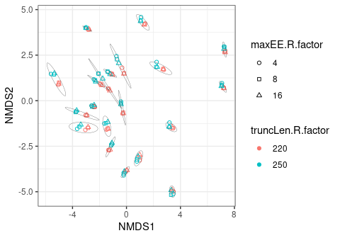

```r
plot_ordination(physeq_joined_nonzero_runC5B2R_hitrunc, ordination_runC52BR_hitrunc, type="samples",
                col="truncLen.R.factor", shape="maxEE.R.factor") +
  stat_ellipse(aes(group=sampleID), lwd=0.1, col="grey20") +
  scale_shape_manual(values=c(21, 22, 24)) +
  # coord_cartesian(xlim=c(-0.096, -0.09), ylim=c(-0.002, 0.001)) +
  NULL
```

```r
ggsave(file.path(PATH_TEST, "results", "sensitivity_ordination_runC5B2R_hitrunc.png"), width=5, height=3.5, units="in")
```

[figure not shown]

```r
# Failed

theme_set(theme_bw())
sample_data(physeq_joined_nonzero_runCBTWG)[,"maxEE.R.factor"] <- as.factor(get_variable(physeq_joined_nonzero_runCBTWG, "maxEE.R"))
plot_ordination(physeq_joined_nonzero_runCBTWG, ordination, type="samples",
                col="truncLen.R", shape="maxEE.R.factor") +
  # stat_ellipse(aes(group=sampleID), lwd=0.1, col="grey20")
  # coord_cartesian(xlim=c(-0.096, -0.09), ylim=c(-0.002, 0.001)) +
  NULL
```

```r
ggsave(file.path(PATH_TEST, "results", "sensitivity_ordination_runCBTWG.png"), width=5, height=3.5, units="in")
```

```r
ordination_scores <- scores(ordination)
```

Test statistical significance using permANOVA.

First run permANOVA using all three levels of `truncLen.R`.

```r
ps_joined_dist <- vegdist(otu_table(physeq_joined_nonzero_runC5B2R))
```

```r
adonis(ps_joined_dist ~ maxEE.R + truncLen.R,
       data = as(sample_data(physeq_joined_nonzero_runC5B2R), "data.frame"),
       strata = get_variable(physeq_joined_nonzero_runC5B2R, "sampleID"),
       permutations=999)
```

```
#>
#> Call:
#> adonis(formula = ps_joined_dist ~ maxEE.R + truncLen.R, data = as(sample_data(physeq_joined_nonzero_runC5B2R),      "data.frame"), permutations = 999, strata = get_variable(physeq_joined_nonzero_runC5B2R,      "sampleID"))
#>
#> Blocks:  strata
#> Permutation: free
#> Number of permutations: 999
#>
#> Terms added sequentially (first to last)
#>
#>             Df SumsOfSqs MeanSqs F.Model      R2 Pr(>F)
#> maxEE.R      1     0.052  0.0521  0.1233 0.00065  1.000
#> truncLen.R   1     5.473  5.4730 12.9591 0.06818  0.001 ***
#> Residuals  177    74.752  0.4223         0.93117
#> Total      179    80.277                 1.00000
#> ---
#> Signif. codes:  0 '***' 0.001 '**' 0.01 '*' 0.05 '.' 0.1 ' ' 1
```

Also, use betadisper to ensure homogeneity of within-group variances (dispersion). Heterogeneity of within-group variances may be confounded with distances between groups in the permANOVA test.

```r
beta_disper <- vegan::betadisper(ps_joined_dist, get_variable(physeq_joined_nonzero_runC5B2R, "truncLen.R"))
anova(beta_disper)
```

```
#> Analysis of Variance Table
#>
#> Response: Distances
#>            Df  Sum Sq  Mean Sq F value    Pr(>F)
#> Groups      2 0.10185 0.050926   35.42 1.152e-13 ***
#> Residuals 177 0.25449 0.001438
#> ---
#> Signif. codes:  0 '***' 0.001 '**' 0.01 '*' 0.05 '.' 0.1 ' ' 1
```

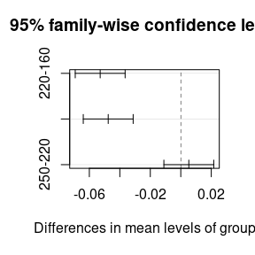

```r
mod.HSD <- TukeyHSD(beta_disper)
plot(mod.HSD)
```

Next re-run permANOVA using only top two levels of `truncLen.R`.

```r
ps_joined_dist_hitrunc <- vegdist(otu_table(physeq_joined_nonzero_runC5B2R_hitrunc))
```

```r
adonis(ps_joined_dist_hitrunc ~ maxEE.R + truncLen.R,
       data = as(sample_data(physeq_joined_nonzero_runC5B2R_hitrunc), "data.frame"),
       strata = get_variable(physeq_joined_nonzero_runC5B2R_hitrunc, "sampleID"),
       permutations=999)
```

```
#>
#> Call:
#> adonis(formula = ps_joined_dist_hitrunc ~ maxEE.R + truncLen.R,      data = as(sample_data(physeq_joined_nonzero_runC5B2R_hitrunc),          "data.frame"), permutations = 999, strata = get_variable(physeq_joined_nonzero_runC5B2R_hitrunc,          "sampleID"))
#>
#> Blocks:  strata
#> Permutation: free
#> Number of permutations: 999
#>
#> Terms added sequentially (first to last)
#>
#>             Df SumsOfSqs MeanSqs F.Model      R2 Pr(>F)
#> maxEE.R      1     0.078 0.07803 0.19574 0.00166  0.001 ***
#> truncLen.R   1     0.224 0.22413 0.56228 0.00477  0.001 ***
#> Residuals  117    46.638 0.39861         0.99356
#> Total      119    46.940                 1.00000
#> ---
#> Signif. codes:  0 '***' 0.001 '**' 0.01 '*' 0.05 '.' 0.1 ' ' 1
```

Also, use betadisper to ensure homogeneity of within-group variances (dispersion). Heterogeneity of within-group variances may be confounded with distances between groups in the permANOVA test.

```r
beta_disper_hitrunc <- vegan::betadisper(ps_joined_dist_hitrunc, get_variable(physeq_joined_nonzero_runC5B2R_hitrunc, "truncLen.R"))
anova(beta_disper_hitrunc)
```

```
#> Analysis of Variance Table
#>
#> Response: Distances
#>            Df   Sum Sq   Mean Sq F value Pr(>F)
#> Groups      1 0.000833 0.0008330  0.3998 0.5284
#> Residuals 118 0.245878 0.0020837
```

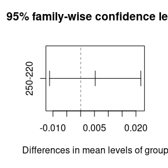

```r
mod.HSD_hitrunc <- TukeyHSD(beta_disper_hitrunc)
plot(mod.HSD_hitrunc)
```

**In conclusion,** both `truncLen.R` and `maxEE.R` affect beta-diversity inference, though to different extents. `truncLen.R` affects mean community composition and within-group variance (dispersion) in a non-linear fashion, with drastically different results for the lowest level of `truncLen.R` tested (`truncLen.R == 160`); This is probably due to the large drop-off in read volume at the merging step due to insufficient read overlap. When ANOVA is constrained to only the higher two levels of `truncLen.R`, both `truncLen.R` and `maxEE.R` are found to be significant in determining mean community composition, but with very small effect sizes.